# 17maggio2019

Carlotta Medana

17/5/2019

# First lession: read dataset

We read the data from the csv file `Advertising.csv`

```r
setwd("~/Desktop/Analisi")
adv <- read.csv("csv/Advertising.csv")
```

We want to have a function m that can predict the numbers of sales in 1000’s depending by the advertising on Tv, Radio and Newspapers.

# Second lession: exercises

## Esercizio 1

1. Plot and compare them using R

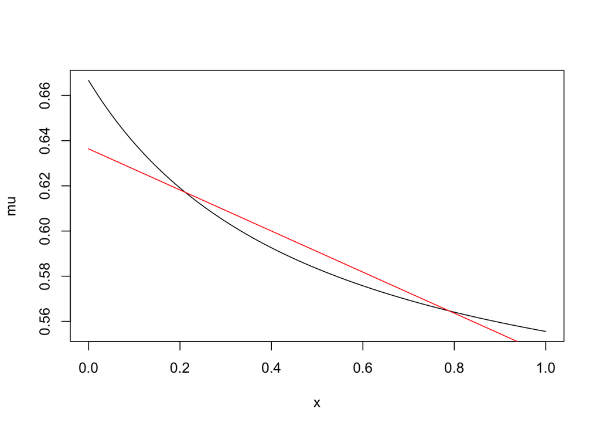

```r
library(ggplot2)
mu <- function(x) {
  return((3*x+2)/(6*x+3))
}
m <- function(x) {
  return (7/11 - 1/11*x)
}
plot(mu)
plot(m, col = "red", add = TRUE)
```

2. Simulate 100 variables from the random variable $E(Y|X=x)$

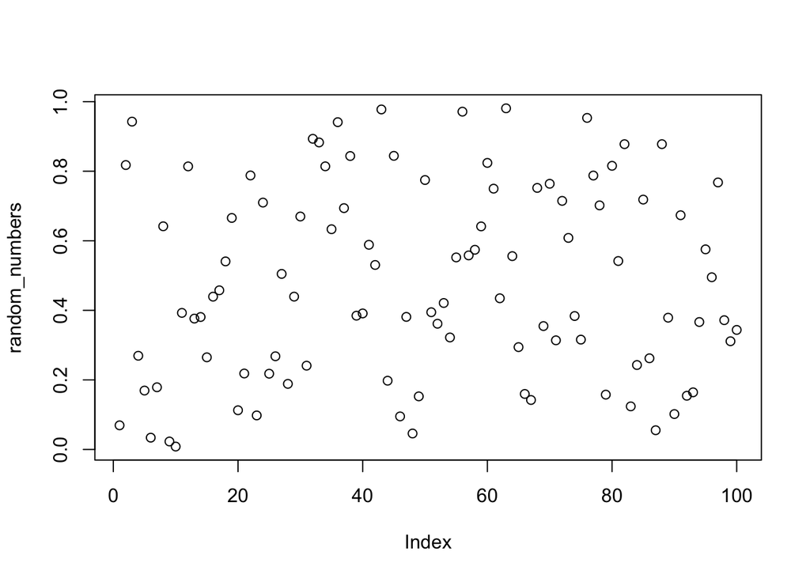

```r
set.seed(12)
random_numbers = runif(100, 0, 1)
plot(random_numbers)
```

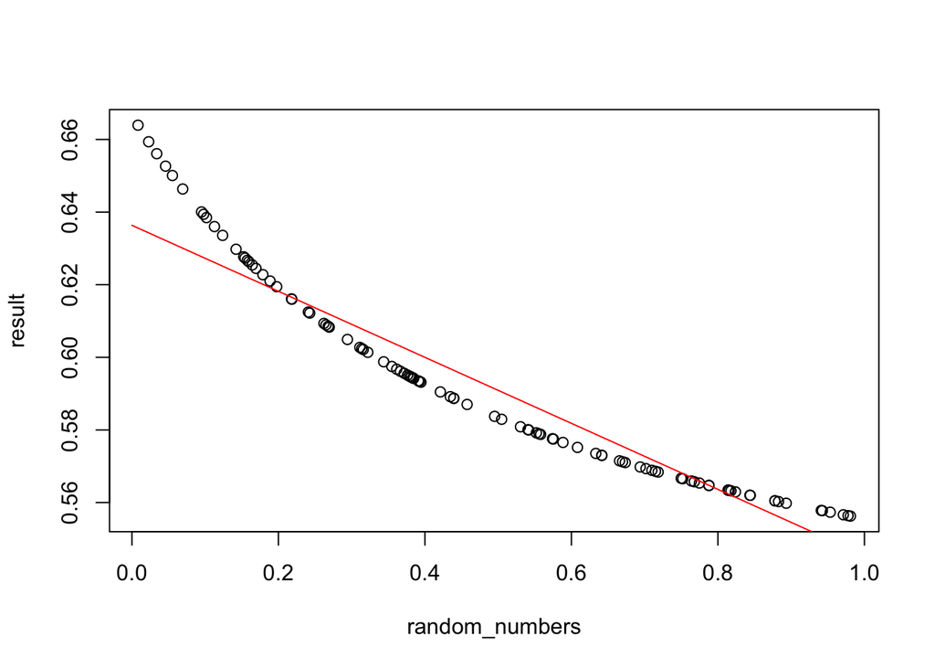

```r
result = mu(random_numbers)
plot(random_numbers, result)
plot(m, col = "red", add=TRUE)
```

## Esercizio 3

Covariance and correlation

#### 1. Write a R function that calculates the empirical covariance and the empirical correlation coefficient according the formulas given in the slides.

```r
standard_deviation <- function(x) {
  n <- length(x)
  return (sqrt((1/n * sum( (x - mean(x))^2 ))))
}
empirical_covariance <- function(x, y) {
  if (length(x) != length(y)) {
    stop("The two arrays must have the sime size!")
  } else {
    n <- length(x)
    return (1/n * sum( (x-mean(x))*(y-mean(y)) ))
  }
}
empirical_correlation <- function(x, y) {
  if (length(x) != length(y)) {
    stop("The two arrays must have the sime size!")
  } else {
    n <- length(x)
    sd_x <- standard_deviation(x)
    sd_y <- standard_deviation(y)
    cov_xy <- empirical_covariance(x,y)

    return (cov_xy / (sd_x*sd_y))
  }
}
```

#### 2. Modify the previous function for delaing with missing data in one variable.

You must call this function `check_arrays` in the previously functions that returns the two arrays without `NaN` values.

```r
check_arrays <- function(x, y) {
  x1 <- x[!is.nan(y)]
  y1 <- y[!is.nan(x)]
  x1 <- x1[!is.nan(x1)]
  y1 <- y1[!is.nan(y1)]
  return (list("x" = x1, "y" = y1))
}
```

#### 3. Compare it with `cov` and `cor`. What is the difference?

```r
set.seed(12)
result <- check_arrays(random_numbers, mu(random_numbers))

x <- getElement(result, "x")
y <- getElement(result, "y")
cov <- cov(x, y)
e_cov <- empirical_covariance(x, y)
cor <- cor(x, y)
e_cor <- empirical_correlation(x, y)
```

We can see that the vlues of covariance and empirical covariance are: -0.0074824, -0.0074076;

And the values of correlation and empirical correlation are: -0.9621665, -0.9621665;

So we can note that there aren’t big differences between the values.

#### 4. Download in R the file `ex1.csv`, calculate the empirical correlation between X and Y .

```r
ex1 <- read.csv("csv/ex1.csv")
result <- check_arrays(ex1$X, ex1$Y)

x <- getElement(result, "x")
y <- getElement(result, "y")

empirical_correlation(x, y)
```

```
## [1] -0.7105549
```

#### 5. Now calculate the 5 correlations when $Z = 1, 2, . . . , 5$. Could you give an explanation of this results

```r
x1 <- ex1$X[ex1$Z == 1]
y1 <- ex1$Y[ex1$Z == 1]

x2 <- ex1$X[ex1$Z == 2]
y2 <- ex1$Y[ex1$Z == 2]

x3 <- ex1$X[ex1$Z == 3]
y3 <- ex1$Y[ex1$Z == 3]

x4 <- ex1$X[ex1$Z == 4]
y4 <- ex1$Y[ex1$Z == 4]

x5 <- ex1$X[ex1$Z == 5]
y5 <- ex1$Y[ex1$Z == 5]
```

- $Z = 1$: correlation = 0.7494208
- $Z = 2$: correlation = 0.6090346
- $Z = 3$: correlation = 0.8028082
- $Z = 4$: correlation = 0.7272744
- $Z = 5$: correlation = 0.7678468

We can note that in this cases the correlation is higher than the correlation between X and Y without consider Z.

#### 6. Find a real data example for three variables X, Y, Z for which Z is a confounder.

For example we can consider a dataset that rappresent the increase of the economy in past 50 years and add a confounder that divide the dataset in two parts: poor people and rich people.

It makes me think that the correlation between the increase and the years without the confound could be medium and with the confounder could be higher.